# CA4

## Introduction

The fourth assignment is based on transforming a large dataset into text format (over 5000 lines of text)

Dataset consist of the GitHup updates by different users.

I scrubed (cleaned) the data and placed it into the relevant objects.

After scrubbing dataset I gained 422 different sets of commit objects.

In this report I will analyse 422 commit objects that are stored in the list by using Python and will come up with interesting statistics.

My code for calculating the analysis will be documented and tested.

## Python sript preparation

```python
#set a directory
import os
os.chdir('D://DBS//5.Programming_for_big_data//github//pz_pbd//CA4')

#create a function which would read file
def read_file(changes_file):
    # use strip to strip out spaces and trim the line
    #strip each line in the inserted file, and
    #return after for loop have checked all file
    return [line.strip() for line in open(changes_file, 'r')]
```

```python
#create commit class
class Commit (object):

    #create commit instance variables
    def __init__ (self, revision, author, date, time, \
                  number_of_lines, change_path = '', comment = ''):
        self.revision = revision
        self.author = author
        self.date = date
        self.time = time
        self.number_of_lines = number_of_lines
        self.change_path = change_path
        self.comment = comment

    #create instance which return commits as a dictionary
    def to_dic(self):
        return {'revision': self.revision, \
                'author': self.author, 'date': self.date, \
                'time': self.time, \
                'number of lines': self.number_of_lines , \
                'changed path': self.change_path, 'comment': self.comment}

    #return instance variable
    #return number of lines as a string, and join comments
    #the reason why we need to join comments is
    #because we can have multiple lines comments
    def __repr__ (self):
        return self.revision+ ',' + self.author + ',' + self.date + \
    ',' + self.time + ',' + str(self.number_of_lines) + ',' \
    + ' '.join(self.change_path) + ',' + ' '.join(self.comment) + '\n'
```

```python
import pandas as pd
#create function which returns data frame of commits
def to_df(data):
    commits = []
    for commit in data:
        commits.append(commit.to_dic())
    return pd.DataFrame(commits)


#get commits function will help us to break information from each commit
def get_commits(data):
    #each commit is separated by 72 hifins
    sep = 72*'-'
    #create a list to store each commit
    commits = []
    #first index starts in the line 0
    index = 0
    #while our index is less than data lenght
    while index < len(data):
        try:
            # find each line of the commit
            #and split by the separator |
            #index + 1 because line starts one line lower than index line
            details = data[index + 1].split('|')
            #call class commit and add details to the variable
            #commit as per class
            commit = Commit(details[0].strip(),
                details[1].strip(),
                details[2].strip().split(' ')[0],
                details[2].strip().split(' ')[1],
                #get number of lines and return as int
                int(details[3].strip().split(' ')[0]))
            #set file end index
            #build in function looks for empty line index and
            #return that index (use build in index function)
            #look for empty lines and stop looking once found
            change_file_end_index = data.index ('', index + 1)
            #changed path line starts from the third line
            commit.change_path = data[index +3 : change_file_end_index]
            #get comments
            commit.comment = data [change_file_end_index + 1:
                change_file_end_index + 1 + commit.number_of_lines]
            # add details to the list of commits
            commits.append(commit)
            #find for a next 72 hifins
            #look for next index in the file which starts with
            #72 hifins, and update index possition
            index = data.index(sep, index + 1)
        except IndexError:
            #then index equal to len of data program stops
            index = len(data)
    #return all commits
    return commits
```

### Test Functions

To make sure that my functions work, I am going to test each of them separately.

Going to check:

- Length of the dataset
- Length of commit objects
- Who is the author at index 420 position in commits list
- Revision number at index 0 possition in commits list
- Comments at index 23 possition in commits list
- Changed paths at index 40 possition in commits list
- Who is the author at index 9 position in the the data frame

```python
if __name__ == '__main__':
    #open the file - and read all lines.
    changes_file = 'changes_python.log'
    #assign all lines to data variable
    data = read_file(changes_file)
    #get commits from get_commits function and insert data variable
    commits = get_commits(data)
    #assign commits, to the data_frame variable by using to_df function
    data_frame = to_df(commits)
```

```python
    #print number of lines from the dataset
    print(len(data))
```

```
5255
```

```python
    #print length of commit objects
    #from this commits variable I will start forming my dataframe
    print(len(commits))
```

```
422
```

```python
    #print author at the 420 index position from the commit list
    print(commits[420].author)
```

```
Jimmy
```

```python
    #print revision at the 0 index position from the commit list
    print(commits[0].revision)
```

```
r1551925
```

```python
    #print comment at the 23 index postion from the commit list
    print (commits[23].comment)
```

```
['SFR-108 : Create bilingual French/English translated Android application for SFR', '-----------', 'three dots. "..."']
```

```python
    #print changed paths at the 40 index position from the commit list
    print (commits[40].change_path)
```

```
['A /cloud/personal/client-international/android/branches/android-15.2-solutions/libs/ui/res/layout/permission_list_item.xml (from /cloud/personal/client-international/android/branches/android-15.2-solutions-att-m/libs/ui/res/layout/permission_list_item.xml:1548354)']
```

```python
    #print author at the 9 index position from the data frame
    print (data_frame['author'][9])
```

```
Vincent
```

## Analysis by using Python

I will analyse dataset by using Python programming language.

To find ineteresting statistics in 422 commit objects I will use following libraries:

- Pandas
- Numpy
- Matplotlib (visualization)
- Seaborn (visualization)

In this report I will explain step by step how I got my results.

```python
    #import required libraries
    import pandas as pd
    import numpy as np
    import matplotlib.pyplot as plt
    %matplotlib inline
    #Seaborn is a Python visualization library based on matplotlib.
    #It provides a high-level interface for drawing attractive statistical graphics.
    import seaborn as sns
    plt.style.use('fivethirtyeight')
    import warnings
    warnings.filterwarnings('ignore')
```

Once I have imported all required libraries for my analysis I can start to analyse and explore data.

Build in function **.info()** shows that data frame has 422 entries and display all 7 column names.

Below we can see that data frame doesn't have any missing values.

```python
    #display information about a dataset
    data_frame.info()
```

```
<class 'pandas.core.frame.DataFrame'>
RangeIndex: 422 entries, 0 to 421
Data columns (total 7 columns):
author             422 non-null object
changed path       422 non-null object
comment            422 non-null object
date               422 non-null object
number of lines    422 non-null int64
revision           422 non-null object
time               422 non-null object
dtypes: int64(1), object(6)
memory usage: 23.1+ KB
```

To get more familiar with a dataset I will view first 5 lines by using build in function **.head()**

```python
    #display data frame 5 lines
    data_frame.head()
```

|  | author | changed path | comment | date | number of lines | revision | time |
| --- | --- | --- | --- | --- | --- | --- | --- |
| 0 | Thomas | [A /cloud/personal/client-international/androi... | [Renamed folder to the correct name] | 2015-11-27 | 1 | r1551925 | 16:57:44 |
| 1 | Thomas | [M /cloud/personal/client-international/androi... | [Removed unused webview.plan.management and we... | 2015-11-27 | 1 | r1551575 | 09:46:32 |
| 2 | Vincent | [M /cloud/personal/client-international/androi... | [enable all clients] | 2015-11-27 | 1 | r1551569 | 09:38:09 |
| 3 | Thomas | [M /cloud/personal/client-international/androi... | [Chnaged jira url to htps] | 2015-11-27 | 1 | r1551558 | 09:13:26 |
| 4 | /OU=Domain Control Validated/CN=svn.company.net | [M /cloud/personal/client-international/androi... | [[gradle-release] prepare for next development... | 2015-11-27 | 1 | r1551504 | 07:05:41 |

Now once data frame is prepared for analysis I am going to check for unique futures within the data frame.

First off all I will investigate, how many unique authors are in the dataset by using **unique()** function.

```python
    #print unique authors
    data_frame['author'].unique()
```

```
array(['Thomas', 'Vincent',
       '/OU=Domain Control Validated/CN=svn.company.net', 'Jimmy',
       'Freddie', 'Dave', 'ajon0002', 'murari.krishnan', 'Nicky', 'Alan'], dtype=object)
```

Once the list with unique authors are known, I can see that one of the authors name is **/OU=Domain Control Validated/CN=svn.company.net** and I am going to replace this name into **DCV** as a very long name can cause difficulties for further data exploration and visualisation.

```python
    #replace author /OU=Domain Control Validated/CN=svn.company.net into DCV
    #this creates new series of values, so we need to
    #assign this new column to the correct column
    data_frame['author'] = data_frame['author']. \
    replace(['/OU=Domain Control Validated/CN=svn.company.net'], 'DCV')
```

```python
    #print unique authors
    data_frame['author'].unique()
```

```
array(['Thomas', 'Vincent', 'DCV', 'Jimmy', 'Freddie', 'Dave', 'ajon0002',
       'murari.krishnan', 'Nicky', 'Alan'], dtype=object)
```

### The biggest amount of commit objects by Author

Once I have a list of authors ready, I am going to investigate which author was the most active and had created the biggest number of commit objects in the dataset.

By using matplotlib and seaborn I will display authors who have generated the biggest amount of commit objects.

```python
    #count how many different authors have commit objects and group by author
    log_in_per = data_frame[['author' ,'date']].groupby(['author'], \
                                                        as_index = False).count()
    #rename column names and print
    log_in_per = log_in_per.rename(columns = {'author': 'Author', \
                                              'date': 'Commit count'})
    #sort values
    log_in_per = log_in_per.sort_values(['Commit count'], ascending = [False])
    log_in_per
```

|  | Author | Commit count |
| --- | --- | --- |
| 6 | Thomas | 191 |
| 4 | Jimmy | 152 |
| 7 | Vincent | 26 |
| 1 | DCV | 24 |
| 8 | ajon0002 | 9 |
| 3 | Freddie | 7 |
| 0 | Alan | 5 |
| 5 | Nicky | 5 |
| 2 | Dave | 2 |
| 9 | murari.krishnan | 1 |

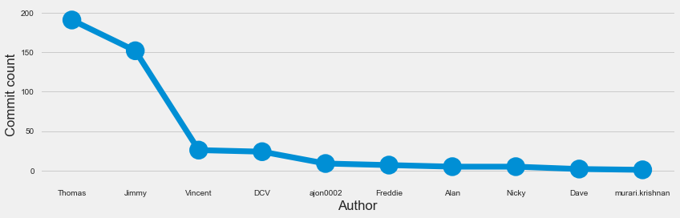

```python
    #create a factor plot
    sns.factorplot('Author', 'Commit count', data = log_in_per, size = 4, \
                   aspect = 3)
```

```
<function matplotlib.pyplot.show>
```

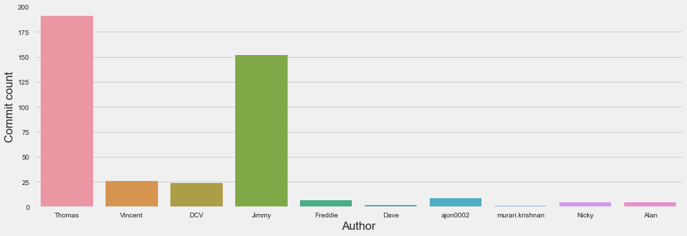

```python
    #create an axis for a plot
    fig, (axis1) = plt.subplots(1,1,figsize=(15,5))

    #display as a bar chart
    ax = sns.barplot('Author', 'Commit count', data = log_in_per, order = \
                     ['Thomas', 'Vincent', \
                    'DCV', 'Jimmy','Freddie', 'Dave', 'ajon0002', \
                    'murari.krishnan', 'Nicky', 'Alan'], ax = axis1)
    ax.set (xlabel = 'Author', ylabel = 'Commit count')
    plt.show
```

Once data visualisation are completed, we can see that author Thomas has the biggest amount of commit objects (191) and the smallest number of commit objects (1) belongs to author murari.krishnan.

To better understand data I created pivot table to display percentage of commit objects belonging to each author and will display visualisation in the pie chart.

```python
    #display overall percentage of commits by author
    commits = int(data_frame['date'].count())
    #add new column to the data frame, and calculate percentage
    log_in_per['Percentage'] = pd.Series.round (((log_in_per['Commit count']*100)/commits),2 )
    log_in_per
```

|  | Author | Commit count | Percentage |
| --- | --- | --- | --- |
| 6 | Thomas | 191 | 45.26 |
| 4 | Jimmy | 152 | 36.02 |
| 7 | Vincent | 26 | 6.16 |
| 1 | DCV | 24 | 5.69 |
| 8 | ajon0002 | 9 | 2.13 |
| 3 | Freddie | 7 | 1.66 |
| 0 | Alan | 5 | 1.18 |
| 5 | Nicky | 5 | 1.18 |
| 2 | Dave | 2 | 0.47 |
| 9 | murari.krishnan | 1 | 0.24 |

```
<function matplotlib.pyplot.show>
```

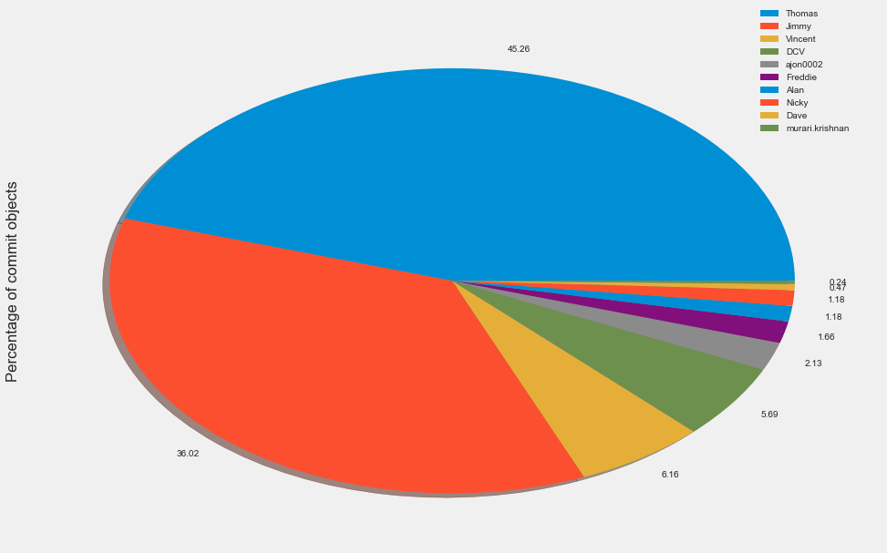

```python
    #create an axis for the pie chart
    fig, (axis1) = plt.subplots(1,1,figsize=(15,10))
    #plot relevant data frame
    ax = log_in_per.plot.pie(y='Percentage', shadow = True, ax = axis1, \
                             labels = log_in_per['Percentage'])
    #set a y label
    ax.set ( ylabel = 'Percentage of commit objects')
    #set a position of the legend to the left top corner
    plt.legend(labels = log_in_per['Author'], bbox_to_anchor=(0.85,1.025), loc="upper left")
    plt.show
```

## Number of comments per author and average number of comments per commit object

Once we know that author Thomas is the most active author and thatthe highest number of commit objects belongs to him, now it will be interesting to see if Thomas generated the biggest number of comment lines and if his average number of comments lines per commit object will be the highest.

I am going to analyse:

- How many comment lines each user have created
- Average number of comments per commit object grouped by author
- If user with the biggest amount of commit objects (Thomas) will have the highest average of commented lines per commit object

```python
    #check how many comment lines each author has created
    number_of_lines = data_frame[['author' ,'number of lines']].groupby(['author'],\
                                                            as_index = False).sum()
    #rename columns
    number_of_lines= number_of_lines.rename(columns = \
                            {'author': 'Author', 'number of lines': 'Commented lines'})
    #sort values in descending order
    number_of_lines = number_of_lines.sort_values(['Commented lines'], ascending = [False])
    number_of_lines
```

|  | Author | Commented lines |
| --- | --- | --- |
| 6 | Thomas | 234 |
| 4 | Jimmy | 154 |
| 7 | Vincent | 80 |
| 1 | DCV | 24 |
| 8 | ajon0002 | 24 |
| 3 | Freddie | 14 |
| 5 | Nicky | 14 |
| 0 | Alan | 8 |
| 2 | Dave | 2 |
| 9 | murari.krishnan | 1 |

```python
    #merge two different data frames
    #1 log in count & Commented lines
    mergged_df = pd.merge( left = log_in_per, right = number_of_lines, \
                          left_on = 'Author', right_on = 'Author' )
    mergged_df
```

|  | Author | Commit count | Percentage | Commented lines |
| --- | --- | --- | --- | --- |
| 0 | Thomas | 191 | 45.26 | 234 |
| 1 | Jimmy | 152 | 36.02 | 154 |
| 2 | Vincent | 26 | 6.16 | 80 |
| 3 | DCV | 24 | 5.69 | 24 |
| 4 | ajon0002 | 9 | 2.13 | 24 |
| 5 | Freddie | 7 | 1.66 | 14 |
| 6 | Alan | 5 | 1.18 | 8 |
| 7 | Nicky | 5 | 1.18 | 14 |
| 8 | Dave | 2 | 0.47 | 2 |
| 9 | murari.krishnan | 1 | 0.24 | 1 |

```python
    #add new column to the data frame
    mergged_df['Average number of comments per commit'] = \
    pd.Series.round(mergged_df['Commented lines'] / mergged_df['Commit count'], 2)
    mergged_df
```

|  | Author | Commit count | Percentage | Commented lines | Average number of comments per commit |
| --- | --- | --- | --- | --- | --- |
| 0 | Thomas | 191 | 45.26 | 234 | 1.23 |
| 1 | Jimmy | 152 | 36.02 | 154 | 1.01 |
| 2 | Vincent | 26 | 6.16 | 80 | 3.08 |
| 3 | DCV | 24 | 5.69 | 24 | 1.00 |
| 4 | ajon0002 | 9 | 2.13 | 24 | 2.67 |
| 5 | Freddie | 7 | 1.66 | 14 | 2.00 |
| 6 | Alan | 5 | 1.18 | 8 | 1.60 |
| 7 | Nicky | 5 | 1.18 | 14 | 2.80 |
| 8 | Dave | 2 | 0.47 | 2 | 1.00 |
| 9 | murari.krishnan | 1 | 0.24 | 1 | 1.00 |

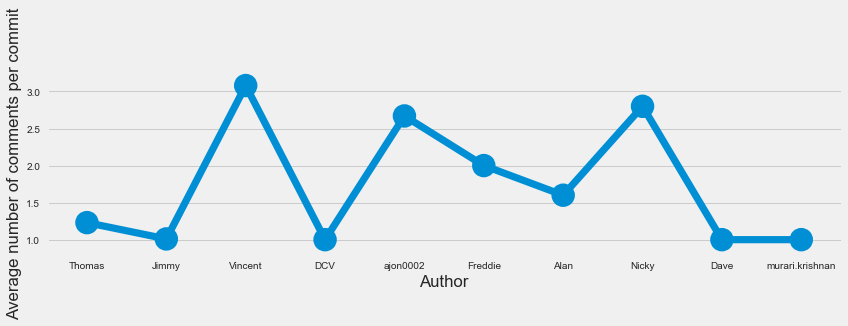

```python
    #create a factor plot
    sns.factorplot('Author', \
                   'Average number of comments per commit', data = mergged_df, \
                   size = 4, aspect = 3)
```

Visualisation of the average number of comments per commit object shows that author Vincent has highest average of 3.08 (comments per commit object) while author Thomas who has the largest number of commit objects (191) has average of 1.23 comments per one commit object.

## The favourit part of the day to create a commit object

We have investigated that the highest amount of commit objects is not necessary going to the lead author to a highest average of comments per one commit object.

Now we can have a look into time frame, when the most commit objects have been generated (In the first part of the day (Morning) between 00:00AM and 12:00PM or in the second part of the day (Evening) between 12:00PM - 00:00AM).

```python
    #strip time into hours minutes and seconds
    data_frame['hours'], data_frame['minutes'], data_frame['seconds'] = data_frame['time'].str.split(':',2).str

    #add additional column in the dataframe,
    #0 = first half of the day, 1 = second half of the day
    data_frame['day_time'] = data_frame['hours']

    #repalce first half of the day values to 0
    data_frame['day_time'] = data_frame['day_time'].replace(['00', '01', \
    '02', '03', '04', '05','06','07','08','09','10','11'], '0')

    #repalce second half of the day values to 1
    data_frame['day_time'] = data_frame['day_time'].replace(['12', '13', '14', '15',  \
          '16','17', '18','19','20','21','22','23', '24'], '1')
```

```python
    #count how many commits done in the morning and in the evening
    count_daytime = data_frame[['day_time' ,'revision']].groupby(['day_time'], as_index = False).count()
    #Replace value 0 into str Morning
    count_daytime['day_time'] = count_daytime['day_time'].replace(['0'], 'Morning')
    #replace value 1 into str Evening
    count_daytime['day_time'] = count_daytime['day_time'].replace(['1'], 'Evening')
    #connect two values for visualisation purpose
    count_daytime['visual'] = count_daytime[['day_time' ,'revision']].apply(lambda x : '{} = {}'.format(x[0],x[1]), \
                                                  axis=1)
    #display
    count_daytime
```

|  | day_time | revision | visual |
| --- | --- | --- | --- |
| 0 | Morning | 138 | Morning = 138 |
| 1 | Evening | 284 | Evening = 284 |

```python
    #count how many comments made in the morning and howe many in the evening
    number_of_lines_time = data_frame[['day_time' ,'number of lines']].groupby(['day_time'], as_index = False).sum()
    #Replace value 0 into str Morning
    number_of_lines_time['day_time'] = number_of_lines_time['day_time'].replace(['0'], 'Morning')
    #replace value 1 into str Evening
    number_of_lines_time['day_time'] = number_of_lines_time['day_time'].replace(['1'], 'Evening')
    #connect two values for visualisation purpose
    number_of_lines_time['visual'] = number_of_lines_time[['day_time' , 'number of lines']].apply(lambda x : '{} = {}'.format(x[0],x[1]), \
                                                                  axis=1)
    #display
    number_of_lines_time
```

|  | day_time | number of lines | visual |
| --- | --- | --- | --- |
| 0 | Morning | 173 | Morning = 173 |
| 1 | Evening | 382 | Evening = 382 |

```
<function matplotlib.pyplot.show>
```

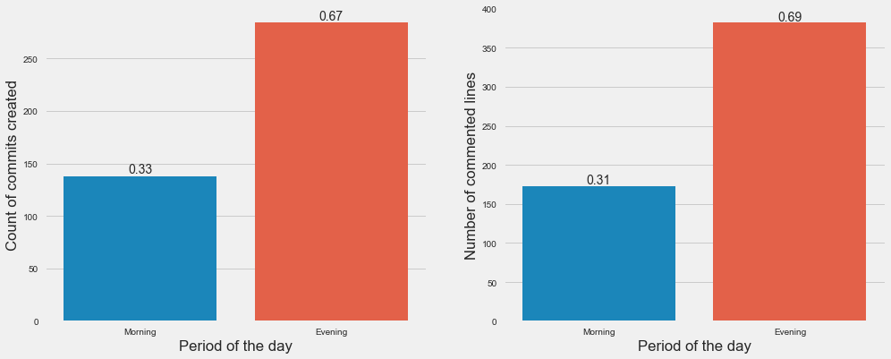

```python
    #create sub plots
    fig, (axis1,axis2) = plt.subplots(1,2,figsize=(15,6))

    #create sns barplot
    ax = sns.barplot(x='day_time', y='revision', \
                     data=count_daytime, ax=axis1, order=['Morning','Evening'])
    ax.set (xlabel = 'Period of the day', ylabel = 'Count of commits created')


    #total is the length of the commits
    total = len(data_frame['revision'])
    for p in ax.patches:
        height = p.get_height()
        ax.text(p.get_x()+p.get_width()/2.,
            height + 3,
            '{:1.2f}'.format(height/total),
            ha="center")
    plt.show


    #create sns barplot
    ax = sns.barplot(x='day_time', y='number of lines', \
                     data=number_of_lines_time, ax=axis2, order=['Morning','Evening'])
    ax.set (xlabel = 'Period of the day', ylabel = 'Number of commented lines')

    #total is a sum of commented lines in a dataframe
    total = sum(number_of_lines_time['number of lines'])
    for p in ax.patches:
        height = p.get_height()
        ax.text(p.get_x()+p.get_width()/2.,
            height + 3,
            '{:1.2f}'.format(height/total),
            ha="center")
    plt.show
```

```
<function matplotlib.pyplot.show>
```

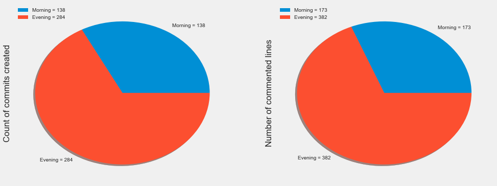

```python
    #create sub plots
    fig, (axis1,axis2) = plt.subplots(1,2,figsize=(15,6))

    ax = count_daytime.plot.pie(y='revision', shadow = True, ax = axis1, labels = count_daytime['visual'])
    ax.set ( ylabel = 'Count of commits created')
    plt.show

    ax = number_of_lines_time.plot.pie(y='number of lines', shadow = True, ax = axis2, labels = number_of_lines_time['visual'])
    ax.set ( ylabel = 'Number of commented lines')
    plt.show
```

Visualisation represents that authors are more active and create more commit objects in the evening time. Overall 67 % of commit objects were created between 12:00PM and 00:00AM, while 69 % of comment lines were created as well in the same time frame.

It will be interesting to see if all authors have been more creative in the evening time. Lets check proportion of generated commit objects and commented lines by each author in the evening and morning time.

```python
    #add additional column to the data frame
    data_frame['day_time_str'] =  \
    data_frame['day_time']
    #replace int 0 to str Morning
    data_frame['day_time_str'] = \
    data_frame['day_time_str'].replace(['0'], 'Morning')
    #replace int 1 to str Evening
    data_frame['day_time_str'] = \
    data_frame['day_time_str'].replace(['1'], 'Evening')


    #look for a size of each option (Evening, Morning) grouped by author and str and make a count
    authors_time_commits = \
    data_frame.groupby(['author' ,'day_time_str']).count()


    #with out hierachy, we need to unstack grouped data frame
    authors_time_commits = \
    data_frame.groupby(['author' ,'day_time_str']).count().unstack()
    authors_time_commits = authors_time_commits['revision']
    authors_time_commits
```

| day_time_str author | Evening | Morning |
| --- | --- | --- |
| Alan | 2.0 | 3.0 |
| DCV | 18.0 | 6.0 |
| Dave | 1.0 | 1.0 |
| Freddie | 2.0 | 5.0 |
| Jimmy | 113.0 | 39.0 |
| Nicky | 5.0 | NaN |
| Thomas | 114.0 | 77.0 |
| Vincent | 19.0 | 7.0 |
| ajon0002 | 9.0 | NaN |
| murari.krishnan | 1.0 | NaN |

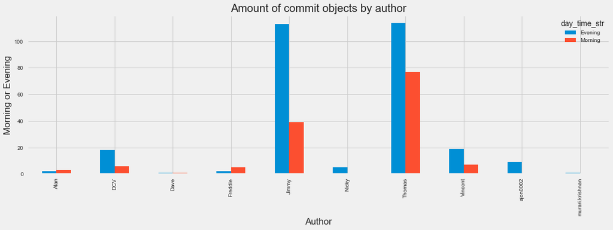

```python
    #create an axis for the plot
    fig, (axis1) = plt.subplots(1,1,figsize=(17,5))
    plot = authors_time_commits.plot.bar(stacked=False, title="Amount of commit objects by author", ax = axis1)
    plot.set_xlabel("Author")
    plot.set_ylabel("Morning or Evening")
```

```python
    #data frame grouped by author and sum of comments
    authors_time_comments = \
    data_frame.groupby(['author' ,'day_time_str']).sum()
    #with out hierachy
    authors_time_comments = \
    data_frame.groupby(['author' ,'day_time_str']).sum().unstack()
    authors_time_comments
```

| day_time_str author | number of lines Evening | number of lines Morning |
| --- | --- | --- |
| Alan | 3.0 | 5.0 |
| DCV | 18.0 | 6.0 |
| Dave | 1.0 | 1.0 |
| Freddie | 4.0 | 10.0 |
| Jimmy | 114.0 | 40.0 |
| Nicky | 14.0 | NaN |
| Thomas | 141.0 | 93.0 |
| Vincent | 62.0 | 18.0 |
| ajon0002 | 24.0 | NaN |
| murari.krishnan | 1.0 | NaN |

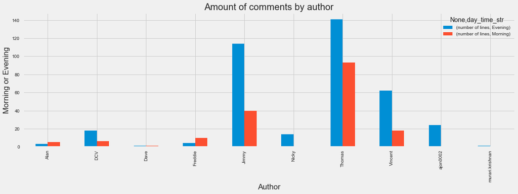

```python
    #create an axis for the plot
    fig, (axis1) = plt.subplots(1,1,figsize=(17,5))
    plot = authors_time_comments.plot.bar(stacked=False, title="Amount of comments by author", ax = axis1)
    plot.set_xlabel("Author")
    plot.set_ylabel("Morning or Evening")
```

Visualisations illiustrate that from 10 authors only two (Alan & Freddie) have created more commit objects and generated more comment lines durring the morning time than a night time. For this reason we can assume that the biggest amount of commit objects and comments were generated durring the evening time between 12:00PM and 00:00AM.